# Is the US balance of trade sustainable?

## Theoretical Background of Sustainability in Trade

Deficit sustainability is testable from this benchmark model [1]:

\begin{equation*} EX_{t}=\alpha_{0}+\alpha_{1} IM_{t}+\varepsilon_{t}, \end{equation*}

where EX, IM and e are export, import and errors, respectively.

For an economy to meet its intertemporal budget constraint, it is imperative that the error term (\varepsilon_{t}) be stationary, as per the necessary condition (weak form). Failure to fulfill this requirement would indicate a malfunctioning economy that cannot meet its budget constraint, ultimately leading to a debt default, according to [2].

It is worth mentioning that in a weak sense, deficit sustainability implies that exports and imports move in tandem in the long run, but the coefficient of imports on exports (alpha1) is less than 1. This indicates that the economy must import more than $1 worth of goods to generate $1 worth of exports. Assuming that the two series move together (i.e., are cointegrated), the closer the coefficient is to 1, the greater the budget's sustainability.

From the Cambridge dictionary, the meaning of "sustainable" is

1- able to continue over a period of time: That sort of extreme diet is not sustainable over a long period. Solutions put in place now must be sustainable.

2- Environment specialized causing, or made in a way that causes, little or no damage to the environment and therefore able to continue for a long time:

A large international meeting was held with the aim of promoting sustainable development in all countries. The website encourages sustainable fashion through swapping.

Let's we start getting data from Federal Reserve Economic Data (FRED):

FRED Database is an extensive compilation of macroeconomic data for the United States, as well as for an increasing number of countries worldwide. This particular illustration involves downloading a small set of macroeconomic data directly from FRED and consolidating it into a single DataFrame. The data available in FRED can be accessed in CSV format using the following url pattern: https://fred.stlouisfed.org/graph/fredgraph.csv?id=CODE, where CODE represents the series code. The dataset used in this example comprises Exports of Goods and Services (EXPGS) and Imports of Goods and Services (IMPGS).

Both of data has measured units: Billions of Dollars, Seasonally Adjusted Frequency: Quarterly

The period of the data is 1947:Q1-2022:Q4:

```python
from pandas import read_csv
from pandas.plotting import scatter_matrix
from pandas import DataFrame

codes = ['EXPGS','IMPGS']
names = ['Exports of Goods and Services','Imports of Goods and Services']
# r to disable escape
base_url = r'https://fred.stlouisfed.org/graph/fredgraph.csv?id={code}'
```

The list of series is

```python
data = []
for code in codes:
    print(code)
    url = base_url.format(code=code)
    data.append(read_csv(url))
```

```
EXPGS
IMPGS
```

Subsequently, the data is combined into a unified DataFrame by creating a dictionary in which the codes are the keys and the corresponding Series obtained from each DataFrame downloaded are the values. In this block, the zip function is utilized to effortlessly concatenate two lists into a singular iterable.

```python
time_series={}
for code, d in zip(codes,data):
    d.index = d.DATE
    time_series[code]=d[code]

merged_data = DataFrame(time_series)
print(merged_data)
```

```
               EXPGS     IMPGS
DATE
1947-01-01    18.394     7.519
1947-04-01    19.497     8.203
1947-07-01    19.433     7.663
1947-10-01    17.636     8.347
1948-01-01    16.917     9.624
...              ...       ...
2021-10-01  2733.037  3647.745
2022-01-01  2811.225  3927.908
2022-04-01  3038.844  4074.409
2022-07-01  3064.971  3955.795
2022-10-01  3003.247  3857.366

[304 rows x 2 columns]
```

```python
merged_data.tail()
```

| DATE | EXPGS | IMPGS |
| --- | --- | --- |
| 2021-10-01 | 2733.037 | 3647.745 |
| 2022-01-01 | 2811.225 | 3927.908 |
| 2022-04-01 | 3038.844 | 4074.409 |
| 2022-07-01 | 3064.971 | 3955.795 |
| 2022-10-01 | 3003.247 | 3857.366 |

```python
# Calculate logarithm to base 2

import pandas as pd
import numpy as np

data = np.log2(merged_data)
data.tail()
```

| DATE | EXPGS | IMPGS |
| --- | --- | --- |
| 2021-10-01 | 11.416289 | 11.832789 |
| 2022-01-01 | 11.456983 | 11.939545 |
| 2022-04-01 | 11.569307 | 11.992375 |
| 2022-07-01 | 11.581658 | 11.949752 |
| 2022-10-01 | 11.552307 | 11.913400 |

Let's have a closer look at the series. Trends in US's exports and imports are plotted by

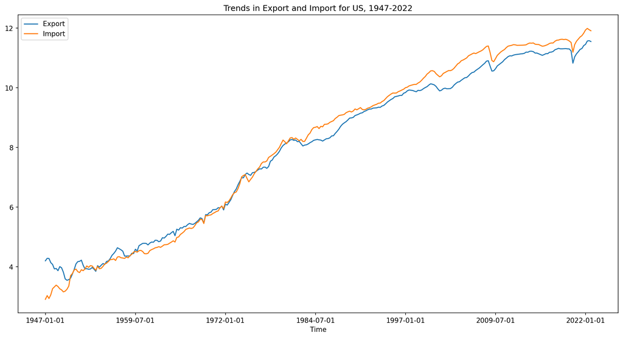

```python
import matplotlib.pyplot as plt


# code
# Visualizing The Open Price of all the stocks

# to set the plot size
plt.figure(figsize=(16, 8), dpi=150)

# using plot method to plot open prices.
# in plot method we set the label and color of the curve.
data['EXPGS'].plot(label='Export')
data['IMPGS'].plot(label='Import')

# adding title to the plot
plt.title('Trends in Export and Import for US, 1947-2022')

# adding Label to the x-axis
plt.xlabel('Time')

# adding legend to the curve
plt.legend()
```

Until 70s, export exports were more than imports. However, after 70s, the equilibrium has been changing against imports. Clearly, these two series are not covariance stationary. I also consider adf unit root test. In ADF unit root test, under the $H_{0}$, the series has a unit root.

```python
from statsmodels.tsa.stattools import adfuller

#perform Augmented Dickey-Fuller test

resultadfExport = adfuller(data.EXPGS)
print('ADF Statistic: %f' % resultadfExport[0])
print('p-value: %f' % resultadfExport[1])
print('Critical Values:')
for key, value in resultadfExport[4].items():
    print('\t%s: %.3f' % (key, value))
```

```
ADF Statistic: -0.385619
p-value: 0.912472
Critical Values:
	1%: -3.452
	5%: -2.871
	10%: -2.572
```

p-value is not smaller than type I error rate 0.05, so I cannot reject $H_{0}$. What about the stationarity for first differences of the series:

```python
dEXPGS = data.EXPGS.diff()
dEXPGS=dEXPGS.dropna(axis=0)

resultadfdEXPGS = adfuller(dEXPGS)
print('ADF Statistic: %f' % resultadfdEXPGS[0])
print('p-value: %f' % resultadfdEXPGS[1])
print('Critical Values:')
for key, value in resultadfdEXPGS[4].items():
    print('\t%s: %.3f' % (key, value))
```

```
ADF Statistic: -9.519914
p-value: 0.000000
Critical Values:
	1%: -3.452
	5%: -2.871
	10%: -2.572
```

p-value is smaller than type I error rate 0.05, so I can reject $H_{0}$. Below you see the analysis of import:

```python
resultadfIMPGS = adfuller(data.IMPGS)
print('ADF Statistic: %f' % resultadfIMPGS[0])
print('p-value: %f' % resultadfIMPGS[1])
print('Critical Values:')
for key, value in resultadfIMPGS[4].items():
    print('\t%s: %.3f' % (key, value))
```

```
ADF Statistic: -2.093199
p-value: 0.247258
Critical Values:
	1%: -3.453
	5%: -2.872
	10%: -2.572
```

```python
dIMPGS = data.IMPGS.diff()
dIMPGS=dIMPGS.dropna(axis=0)

resultadfdIMPGS = adfuller(dIMPGS)
print('ADF Statistic: %f' % resultadfdIMPGS[0])
print('p-value: %f' % resultadfdIMPGS[1])
print('Critical Values:')
for key, value in resultadfdIMPGS[4].items():
    print('\t%s: %.3f' % (key, value))
```

```
ADF Statistic: -4.818964
p-value: 0.000050
Critical Values:
	1%: -3.453
	5%: -2.872
	10%: -2.572
```

After determine the integration properties of the series let's look cointegration with ARDL approach. Residual-based tests of cointegration encounter a significant challenge in that the researcher must be certain that the underlying regressors in the model are I(1). However, due to the generally low power of unit root tests, the process of testing whether the underlying variables are I(1) may introduce a level of uncertainty into the analysis. To address this issue, an alternative approach has been proposed by [3], which involves estimating an error correction model of an ARDL form for the relevant variables. For example, if I aim to test the presence of a long-term relationship between EX and IM, and I am unsure whether these variables are I(1) or I(0), this approach may prove useful. More specifically, this approach offers a notable benefit in that it exhibits superior small-sample properties compared to both the Johansen and Juselius approach and the Engle and Granger approach.

I do not give more details of ARDL approach but you can find more info from here: https://davegiles.blogspot.com/2015/01/ardl-modelling-in-eviews-9.html.

First of all, we determine lag length of ARDL model by BIC criteria:

```python
from statsmodels.datasets.danish_data import load
from statsmodels.tsa.api import ARDL
from statsmodels.tsa.ardl import ardl_select_order

sel_res = ardl_select_order(data.EXPGS, 4, data[["IMPGS"]], 4, ic="bic", trend="ct")
print(f"The optimal order is: {sel_res.model.ardl_order}")
```

```
The optimal order is: (3, 1)
```

According to the BIC, our best model is ARDL(3,1):

```python
ARDLres = sel_res.model.fit()
ARDLres.summary()
```

ARDL Model Results

| Dep. Variable: | EXPGS | No. Observations: | 304 |
| --- | --- | --- | --- |
| Model: | ARDL(3, 1) | Log Likelihood | 479.826 |
| Method: | Conditional MLE | S.D. of innovations | 0.049 |
| Date: | Wed, 22 Mar 2023 | AIC | -943.652 |
| Time: | 15:08:48 | BIC | -913.995 |
| Sample: | 10-01-1947 | HQIC | -931.784 |
|  | - 10-01-2022 |  |  |

|  | coef | std err | z | P>\|z\| | [0.025 | 0.975] |
| --- | --- | --- | --- | --- | --- | --- |
| const | 0.0893 | 0.026 | 3.446 | 0.001 | 0.038 | 0.140 |
| trend | 0.0003 | 0.000 | 1.659 | 0.098 | -6.49e-05 | 0.001 |
| EXPGS.L1 | 0.9762 | 0.047 | 20.634 | 0.000 | 0.883 | 1.069 |
| EXPGS.L2 | 0.0905 | 0.063 | 1.439 | 0.151 | -0.033 | 0.214 |
| EXPGS.L3 | -0.1883 | 0.042 | -4.473 | 0.000 | -0.271 | -0.105 |
| IMPGS.L0 | 0.6293 | 0.044 | 14.325 | 0.000 | 0.543 | 0.716 |
| IMPGS.L1 | -0.5275 | 0.047 | -11.261 | 0.000 | -0.620 | -0.435 |

Secondly, we access unrestricted Error Correction Mechanism (UECM):

```python
from statsmodels.tsa.api import UECM

ecm = UECM.from_ardl(sel_res.model)
ecm_res = ecm.fit()
ecm_res.summary()
```

UECM Model Results

| Dep. Variable: | D.EXPGS | No. Observations: | 304 |
| --- | --- | --- | --- |
| Model: | UECM(3, 1) | Log Likelihood | 479.826 |
| Method: | Conditional MLE | S.D. of innovations | 8.343 |
| Date: | Wed, 22 Mar 2023 | AIC | -943.652 |
| Time: | 15:03:03 | BIC | -913.995 |
| Sample: | 10-01-1947 | HQIC | -931.784 |
|  | - 10-01-2022 |  |  |

|  | coef | std err | z | P>\|z\| | [0.025 | 0.975] |
| --- | --- | --- | --- | --- | --- | --- |
| const | 0.0893 | 0.026 | 3.446 | 0.001 | 0.038 | 0.140 |
| trend | 0.0003 | 0.000 | 1.659 | 0.098 | -6.49e-05 | 0.001 |
| EXPGS.L1 | -0.1216 | 0.018 | -6.858 | 0.000 | -0.157 | -0.087 |
| IMPGS.L1 | 0.1018 | 0.016 | 6.525 | 0.000 | 0.071 | 0.132 |
| D.EXPGS.L1 | 0.0978 | 0.042 | 2.309 | 0.022 | 0.014 | 0.181 |
| D.EXPGS.L2 | 0.1883 | 0.042 | 4.473 | 0.000 | 0.105 | 0.271 |
| D.IMPGS.L0 | 0.6293 | 0.044 | 14.325 | 0.000 | 0.543 | 0.716 |

From here, we then get cointegration vector:

```python
ecm_res.ci_summary()
```

Cointegrating Vector

|  | coef | std err | t | P>\|t\| | [0.025 | 0.975] |
| --- | --- | --- | --- | --- | --- | --- |
| const | -0.7342 | 0.169 | -4.356 | 0.000 | -1.066 | -0.402 |
| trend | -0.0029 | 0.002 | -1.730 | 0.084 | -0.006 | 0.000 |
| EXPGS.L1 | 1.0000 | 0 | nan | nan | 1.000 | 1.000 |
| IMPGS.L1 | -0.8369 | 0.051 | -16.350 | 0.000 | -0.938 | -0.736 |

This vector means

\begin{equation*} \widehat{EX_{t-1}}=0.73+0.0029trend + 0.84 IM_{t-1}. \end{equation*}

Do not worry about $t-1$, it is almost same as $t$ when $t=T$. So we now we can talk about sustainability of trade imbalances. But first we have to be aware of the validity of cointegration. Let's look at t-statistic and p-value: -16.35 and 0.000<0.05 so the system is cointegrated. Secondly, I look F-test:

```python
ecm_res.bounds_test(case=4, cov_type='nonrobust', cov_kwds=None, use_t=True, asymptotic=True, nsim=10000, seed=None)
```

```
BoundsTestResult
Stat: 16.57512
Upper P-value: 8.56e-10
Lower P-value: 1.58e-10
Null: No Cointegration
Alternative: Possible Cointegration
```

After concluding the existence of a long-term relationship, let's perform another analysis: Which form of intertemporal budget constraint valid for US: weak or strong? To do this, we must test $H_{0}:\alpha_{1}=1$. Overall, our test statistic is calculated as

\begin{equation*} t_{stat}=\frac{\widehat{\alpha_{1}}-1}{s.e.\widehat{\alpha_{1}}}. \end{equation*}

```python
t_stat=(-ecm_res.ci_params.IMPGS-1)/ecm_res.ci_bse.IMPGS
print(t_stat)
```

```
-3.1860211325857444
```

```python
# Import Library
import scipy.stats
q=1-.05/2

# To find the T critical value
tc975=scipy.stats.t.ppf(q,df=308)
tc025=scipy.stats.t.ppf(1-q,df=308)
print(tc975)
print(tc025)
```

```
1.9676960046163405
-1.9676960046163405
```

Because of t-stat=-3.18<-1.96, I reject the null hypothesis that $\alpha_{1}=1$. Finally, I conclude that US satisfies only the weak form of its intertemporal budget constraint.

## References

[1] Narayan, P. K., & Narayan, S. (2019). The sustainability of Fiji's budget deficit: an econometric analysis. [2] Hakkio, C. S., & Rush, M. (1991). Cointegration: how short is the long run?. Journal of international Money and Finance, 10(4), 571-581. [3] Pesaran, M. H., Shin, Y., & Smith, R. J. (2001). Bounds testing approaches to the analysis of level relationships. Journal of applied econometrics, 16(3), 289-326.